# United Nations Voting Records

Author

River Mckegney

*This task is complex. It requires many different types of abilities. Everyone will be good at some of these abilities but nobody will be good at all of them. In order to produce the best product possible, you will need to use the skills of each member of your group.*

**Note**

Note: Since the project folder is already shared as a zip file, using the commands:

- `usethis::use_git()`
- `usethis::use_github()`

might be easier to initiate your github repository.

## Goals for the Activity

- Join multiple data tables together by a common variable(s)
- Create new data sets through the joining of data from various sources
- Combine `join` functions with other `tidyverse` functions

**THROUGHOUT THE Activity** be sure to follow the Style Guide by doing the following:

- load the appropriate packages at the beginning of the Quarto document
- use proper spacing
- *add labels* to all code chunks
- comment at least once in each code chunk to describe why you made your coding decisions
- add appropriate labels to all graphic axes

# Data Description

The data this week comes from Harvard’s Dataverse by way of Mine Çetinkaya-Rundel, David Robinson, and Nicholas Goguen-Compagnoni.

> Original Data citation: Erik Voeten “Data and Analyses of Voting in the UN General Assembly” Routledge Handbook of International Organization, edited by Bob Reinalda (published May 27, 2013). Available at SSRN: http://ssrn.com/abstract=2111149

It was featured on [TidyTuesday](https://github.com/rfordatascience/tidytuesday/blob/master/data/2021/2021-03-23/readme.md)

Here is each data set and its description (you might want to look at the Tidy Tuesday link for the tables already rendered)

`unvotes.csv`

| variable | class | description |
| --- | --- | --- |
| rcid | double | The roll call id; used to join with un_votes and un_roll_call_issues |
| country | character | Country name, by official English short name |
| country_code | character | 2-character ISO country code |
| vote | integer | Vote result as a factor of yes/abstain/no |

```r
# Call dataset unvotes as a tibble
unvotes <- read_csv("data/unvotes.csv")
```

`roll_calls.csv`

| variable | class | description |
| --- | --- | --- |
| rcid | integer | . |
| session | double | Session number. The UN holds one session per year; these started in 1946 |
| importantvote | integer | Whether the vote was classified as important by the U.S. State Department report “Voting Practices in the United Nations”. These classifications began with session 39 |
| date | double | Date of the vote, as a Date vector |
| unres | character | Resolution code |
| amend | integer | Whether the vote was on an amendment; coded only until 1985 |
| para | integer | Whether the vote was only on a paragraph and not a resolution; coded only until 1985 |
| short | character | Short description |
| descr | character | Longer description |

```r
# Call dataset roll_calls as a tibble
roll_calls <- read_csv("data/roll_calls.csv")
```

`issues.csv`

| variable | class | description |
| --- | --- | --- |
| rcid | integer | The roll call id; used to join with unvotes and un_roll_calls |
| short_name | character | Two-letter issue codes |
| issue | integer | Descriptive issue name |

```r
# Call dataset issues as a tibble
issues <- read_csv("data/issues.csv")
```

## Data Exploration

Our goal today is to explore how various members (countries) in the United Nations vote. We have three data sets, what can we determine from each data set separately?

Response by River Mckegney

> With the ‘unvotes’ dataset we can evaluate location data (country level) associated with votes and also a countries vote type. With the ‘roll_calls’ dataset we can suss out the datetime and information about vote meetings held by the United Nations. The ‘issues’ dataset contains pertinent information about the vote topic.

### UN Votes

The first data set, `unvotes` contains data on the `rcid` which is the roll call id for the vote, the country/country code, and how the country voted. What can we learn from the data?

Response by River Mckegney

> We can learn how each country decidided to vote about a specific issue, and what similarities or differences exist between countries representitive views.

Comment on the following code, what is happening in each line? One way to approach seeing what each line does is to highlight the code from before the `pipe` of that line up to the data `unvotes` and use `CTRL + ENTER` to run just the highlighted lines.

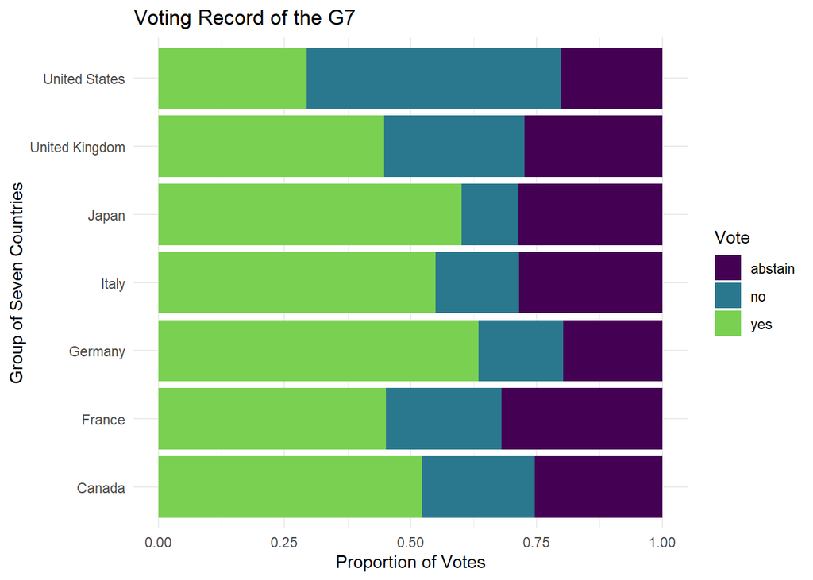

```r
unvotes |>
  count(country, vote) |> # counts total vote types for each country
  group_by(country) |> # groups next calculation by country
  mutate(total = sum(n)) |> # Counts all votes from all types for each  country
  mutate(prop_vote = n/total) |> # Calculates proportion of each vote type
  filter(country %in% c("United States", "Canada",
                        "Germany", "France",
                        "Italy", "Japan",
                        "United Kingdom")) |> # Selects variables from these specific countries
  ggplot(aes(x = country, y = prop_vote,
             fill = vote)) + # Creates a plot with x-axis as countries and y-axis as proportions of votes
  geom_col(position = position_stack()) + # Creates a stacked bar chart
  labs(x = "Group of Seven Countries",
       y = "Proportion of Votes",
       title = "Voting Record of the G7",
       fill = "Vote") + # Labels each axis, and color codes bars by vote type
  theme_minimal() +  # Adds a minimal theme to graph
  scale_fill_viridis_d(end = 0.8) + # Adds specific color palette to chart
  coord_flip() # Flips the axes and stacked bar plot orientation
```

Describe what the graph above demonstrates above UN voting records for the G7

Response by River Mckegney

> From the barplot we can see that from these seven selected couintries, looking at the historical extent of all UN voting that happend (in the dataset), The United States contains the highest count for voting “no” and Germany has the highest count for voting “yes”.

### Roll Calls

The second data set, `roll_calls` has more information on the type of vote, the importance, whether it was a resolution, and date of the vote. What does the following code do?

```r
roll_calls |>
  distinct(short)
```

```
# A tibble: 2,019 × 1
   short
   <chr>
 1 AMENDMENTS, RULES OF PROCEDURE
 2 SECURITY COUNCIL ELECTIONS
 3 VOTING PROCEDURE
 4 DECLARATION OF HUMAN RIGHTS
 5 GENERAL ASSEMBLY ELECTIONS
 6 ECOSOC POWERS
 7 POST-WAR RECONSTRUCTION
 8 U.N. MEMBERS, RELATIONS WITH SPAIN
 9 TRUSTEESHIP AMENDMENTS
10 COUNCIL MEMBER TERM LENGTH
# ℹ 2,009 more rows
```

Description of code results

Response by River Mckegney

> The code block above displays the unique variables (short response descriptions) for the voting topics being decided upon.

We can use the individual data for `roll_calls` to look at the number of votes per year over time.

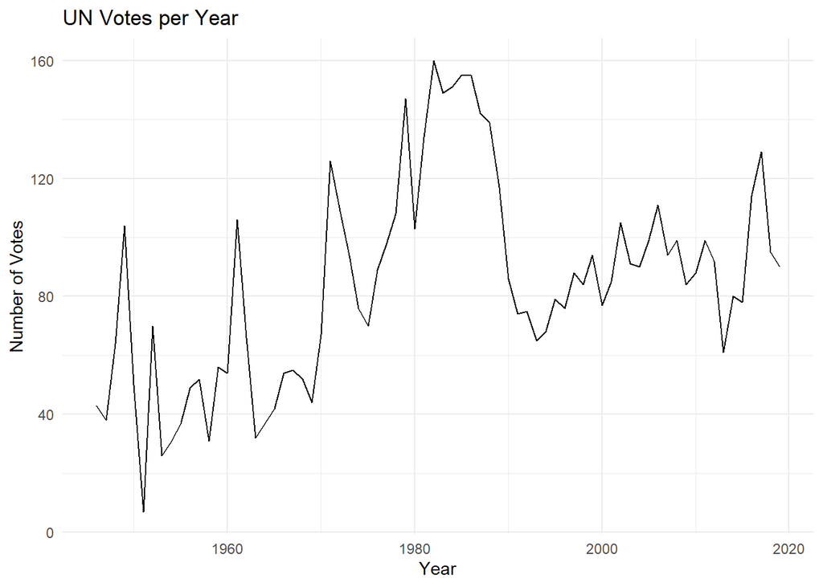

```r
roll_calls |>
  mutate(year = lubridate::year(date)) |> #extracts the year from the date value and creates a new `year` column
  count(year) |> #counts how many votes there were per year assuming each line is an single voting instance
  ggplot(aes(x = year, y = n)) +
  geom_line() +
  labs(x = "Year", y = "Number of Votes",
       title = "UN Votes per Year") +
  theme_minimal()
```

What information is missing from the above graphic that might be useful in understanding the issues the UN commonly votes on?

Response by River Mckegney

> The graph is missing information about the voting topics, most appropriately the short descriptions associated with each UN ballot event in the ‘short’ column of the roll_calls dataset.

We could try and look at the short descriptions, `short`, for each vote with the following code.

```r
roll_calls |>
  count(short)
```

```
# A tibble: 2,019 × 2
   short                                                                       n
   <chr>                                                                   <int>
 1 1ST COMMITTEE, RATIONALIZATION                                              1
 2 30TH ANNIVERSARY, INDEPENDENCE                                              1
 3 3RD SPECIAL SESSION                                                         1
 4 4TH DECADE OF DEVELOPMENT                                                   1
 5 ?ÃƒÂ¡INTERNATIONAL TRADE                                                    1
 6 A global call for concrete action for the total elimination of racism,…     1
 7 A global call for concrete action for the total elimination of racism,…     3
 8 A path to the total elimination of nuclear weapons : resolut                1
 9 A path to total elimination of nuclear weapons : resolution                 1
10 ACCOMODATION, NAIROBI                                                       1
# ℹ 2,009 more rows
```

Does the above information help us understand the voting issues of the UN over time? Explain.

Response by River Mckegney

> Yes, but not quite. The code above counts the total number of discrete vote topics, but does not divy out these counts across the years that they occured. This filtering process could be easily used with the graph above (and perhaps another grouping or filtering function) to illustrate how UN voting counts on specific issues change over time.

### Issues

Finally we have the `issues` data which provides a more general description for each vote on specific issues. Note that not all issues are included in the data set, just the ones related to the 6 issues below:

```r
issues |>
  count(issue)
```

```
# A tibble: 6 × 2
  issue                                    n
  <chr>                                <int>
1 Arms control and disarmament          1092
2 Colonialism                            957
3 Economic development                   765
4 Human rights                          1015
5 Nuclear weapons and nuclear material   855
6 Palestinian conflict                  1061
```

It would be helpful to use the `issues` data with the `roll_calls` data to be able to better understand the voting trends within the UN on at least these 6 issues. To do this, we need to join the data.

# Votes Over Time

Now let’s join our data together to get a better idea of how the UN has voted over time.  
First, look at the number of rows in `issues` and `roll_calls` - do they match? What does this indicate?

```r
dim(issues)
```

```
[1] 5745    3
```

```r
dim(roll_calls)
```

```
[1] 6202    9
```

Response by River Mckegney

> The number of rows do not match between ‘issues’ (5745 rows) and ‘roll_calls’ (6202 rows). This indicates that the issues dataset does not contain all the observations (the historical record of votes data) that roll_calls does.

Now let’s try joining the `roll_calls` with the `issues` data. Compare the following codes to join the data. Describe what each one does and how it differs from the others as a comment in the code chunk. You might need to reference the slides or reading for this week.

```r
roll_calls |>
  left_join(issues, by = "rcid")
```

```
# A tibble: 7,848 × 11
    rcid session importantvote date       unres   amend  para short        descr
   <dbl>   <dbl>         <dbl> <date>     <chr>   <dbl> <dbl> <chr>        <chr>
 1     3       1             0 1946-01-01 R/1/66      1     0 AMENDMENTS,… "TO …
 2     4       1             0 1946-01-02 R/1/79      0     0 SECURITY CO… "TO …
 3     5       1             0 1946-01-04 R/1/98      0     0 VOTING PROC… "TO …
 4     6       1             0 1946-01-04 R/1/107     0     0 DECLARATION… "TO …
 5     7       1             0 1946-01-02 R/1/295     1     0 GENERAL ASS… "TO …
 6     8       1             0 1946-01-05 R/1/297     1     0 ECOSOC POWE… "TO …
 7     9       1             0 1946-02-05 R/1/329     0     0 POST-WAR RE… "TO …
 8    10       1             0 1946-02-05 R/1/361     1     1 U.N. MEMBER… "TO …
 9    11       1             0 1946-02-05 R/1/376     0     0 TRUSTEESHIP… "TO …
10    11       1             0 1946-02-05 R/1/376     0     0 TRUSTEESHIP… "TO …
# ℹ 7,838 more rows
# ℹ 2 more variables: short_name <chr>, issue <chr>
```

```r
# Left joins merge the second or right df y 'issues' by all rows matching the first left df x 'roll_calls'. Missing values of df y across rows are then filled in with NAs.

# Left join = keep all x rows, remove non-matching y rows
```

```r
roll_calls |>
  right_join(issues, by = "rcid")
```

```
# A tibble: 5,745 × 11
    rcid session importantvote date       unres      amend  para short     descr
   <dbl>   <dbl>         <dbl> <date>     <chr>      <dbl> <dbl> <chr>     <chr>
 1     6       1             0 1946-01-04 R/1/107        0     0 DECLARAT… "TO …
 2     8       1             0 1946-01-05 R/1/297        1     0 ECOSOC P… "TO …
 3    11       1             0 1946-02-05 R/1/376        0     0 TRUSTEES… "TO …
 4    11       1             0 1946-02-05 R/1/376        0     0 TRUSTEES… "TO …
 5    18       1             0 1946-02-03 R/1/532        1     0 ECOSOC C… "TO …
 6    19       1             0 1946-02-03 R/1/534        0     0 ECOSOC C… "TO …
 7    24       1             0 1946-12-05 R/1/1229       0     0 ECOSOC E… "TO …
 8    26       1             0 1946-12-06 R/1/1286       0     0 TRUSTEES… "TO …
 9    27       1             0 1946-12-06 R/1/1287/A     0     0 NEW GUIN… "TO …
10    28       1             0 1946-12-06 R/1/1287/B     0     0 RUANDA-U… "TO …
# ℹ 5,735 more rows
# ℹ 2 more variables: short_name <chr>, issue <chr>
```

```r
# Right joins will keep all rows of df y 'issues' and remove unmatched rows of df x 'roll_calls'

# Right join = keep all y rows, remove unmatched x rows
```

```r
roll_calls |>
  full_join(issues, by = "rcid")
```

```
# A tibble: 7,848 × 11
    rcid session importantvote date       unres   amend  para short        descr
   <dbl>   <dbl>         <dbl> <date>     <chr>   <dbl> <dbl> <chr>        <chr>
 1     3       1             0 1946-01-01 R/1/66      1     0 AMENDMENTS,… "TO …
 2     4       1             0 1946-01-02 R/1/79      0     0 SECURITY CO… "TO …
 3     5       1             0 1946-01-04 R/1/98      0     0 VOTING PROC… "TO …
 4     6       1             0 1946-01-04 R/1/107     0     0 DECLARATION… "TO …
 5     7       1             0 1946-01-02 R/1/295     1     0 GENERAL ASS… "TO …
 6     8       1             0 1946-01-05 R/1/297     1     0 ECOSOC POWE… "TO …
 7     9       1             0 1946-02-05 R/1/329     0     0 POST-WAR RE… "TO …
 8    10       1             0 1946-02-05 R/1/361     1     1 U.N. MEMBER… "TO …
 9    11       1             0 1946-02-05 R/1/376     0     0 TRUSTEESHIP… "TO …
10    11       1             0 1946-02-05 R/1/376     0     0 TRUSTEESHIP… "TO …
# ℹ 7,838 more rows
# ℹ 2 more variables: short_name <chr>, issue <chr>
```

```r
# Full joins will display all rows of left df x 'roll_calls' first, as is, then will include any unmatched rows of right df y 'issues'

# Full join = keep both x and y rows, including unmatched ones
```

```r
roll_calls |>
  inner_join(issues, by = "rcid")
```

```
# A tibble: 5,745 × 11
    rcid session importantvote date       unres      amend  para short     descr
   <dbl>   <dbl>         <dbl> <date>     <chr>      <dbl> <dbl> <chr>     <chr>
 1     6       1             0 1946-01-04 R/1/107        0     0 DECLARAT… "TO …
 2     8       1             0 1946-01-05 R/1/297        1     0 ECOSOC P… "TO …
 3    11       1             0 1946-02-05 R/1/376        0     0 TRUSTEES… "TO …
 4    11       1             0 1946-02-05 R/1/376        0     0 TRUSTEES… "TO …
 5    18       1             0 1946-02-03 R/1/532        1     0 ECOSOC C… "TO …
 6    19       1             0 1946-02-03 R/1/534        0     0 ECOSOC C… "TO …
 7    24       1             0 1946-12-05 R/1/1229       0     0 ECOSOC E… "TO …
 8    26       1             0 1946-12-06 R/1/1286       0     0 TRUSTEES… "TO …
 9    27       1             0 1946-12-06 R/1/1287/A     0     0 NEW GUIN… "TO …
10    28       1             0 1946-12-06 R/1/1287/B     0     0 RUANDA-U… "TO …
# ℹ 5,735 more rows
# ℹ 2 more variables: short_name <chr>, issue <chr>
```

```r
# Inner join = Keep only matching rows in both x and y
```

**If we are only interested in retaining the records associated with the `issues` labeled in our data, which join(s) should we use?**

Response by River Mckegney

Now that we know how to join the data, we will use the following code to examine the the voting trends for three of the issues related to conflict/weapons.

Be sure to run the code via the green arrow on the code chunk, as the `case_when()` code can get finicky sometimes and claim an error about a comma in the code when it doesn’t exist. *Comment on the code where indicated* and add your chosen join function

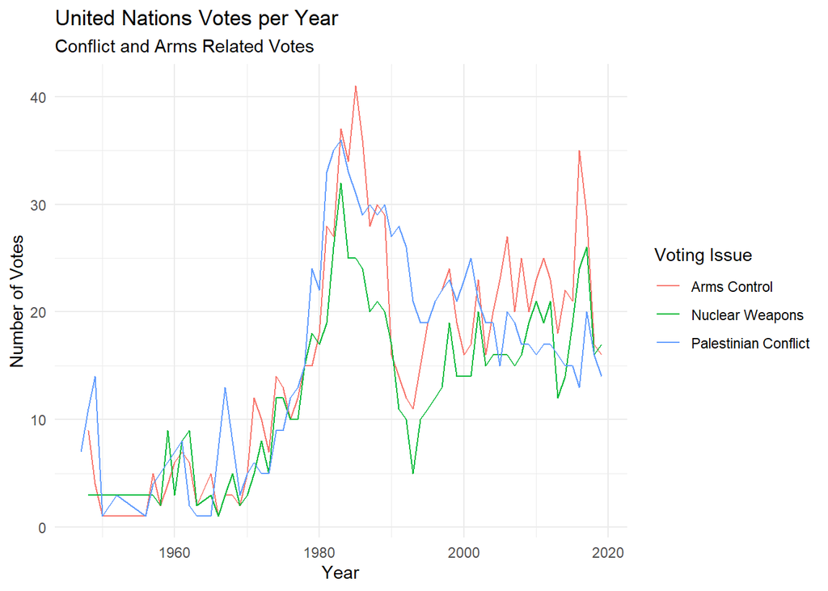

```r
roll_calls |>
  right_join(issues, by = "rcid") |>  #join roll_calls and issues so that just the votes related to the issues data are retained.
  mutate(issue = case_when(
    issue == "Arms control and disarmament" ~ "Arms Control",
    issue == "Nuclear weapons and nuclear material" ~ "Nuclear Weapons",
    issue == "Palestinian conflict" ~ "Palestinian Conflict")) |>   # Here we select and rename each of the variables or topics of interest within the issue column, which effectively bins or groups subjects into a neater format for graphic display

  drop_na(issue) |> #drop NAs for values not defined in the previous line of code
  mutate(year = lubridate::year(date)) |> #create a column `year` that contains the year value
  count(year, issue) |> # Counts the number of votes of a particular issue for a given year
  ggplot(aes(x = year, y = n, group = issue)) + # Creates a graph and id's axes
  geom_line(aes(color = issue)) + # Makes line chart and color codes by issue variables
  labs(x = "Year", y = "Number of Votes",
       title = "United Nations Votes per Year",
       subtitle = "Conflict and Arms Related Votes",
       color = "Voting Issue") +
  theme_minimal()
```

What do you notice? What do you wonder based on the graph created?

Response by River Mckegney

# Challenge 1: Joining all Data

We want to try and create the visualization (see instructions online). To do this, though, we need information from all three data set, `unvotes`, `issues`, and `roll_calls`

We want to join all three data sets together, *maintaining only the votes for which we have identified the general issue* (e.g., Nuclear War, Arms, Economics, etc.). We will save (assign) the data as `un_full`. Fill in the best *join functions* to do maintain just the votes for which we have identified the general issue.

```r
un_full <- unvotes |>
  right_join(issues, by = "rcid") |> # Keep 'issues' rows, remove unmatched unvotes rows
  left_join(roll_calls, by = "rcid") # Retain left x rows, remove unmatched y rows

#View(un_full)
```

Now, we are going to do some data cleaning. Our goal is create a data set that includes the percentage of “yes” votes per country each year. Fill in the missing _________ with the correct verbs. We will call the data table `yes_votes`

```r
yes_votes <- un_full |>
  select(country, issue, date, vote) |>  #keep just the columns for country, issue, date, vote
  mutate(year = lubridate::year(date)) |> #create a new variable called year
  group_by(country, year, issue) |> #group country, year, issue together to prepare for subsequent analysis
  summarize(percent_yes = mean(vote == "yes")) |> #calculate the proportion of yes votes
  mutate(issue = case_when(
    issue == "Arms control and disarmament" ~ "Arms Control",
    issue == "Nuclear weapons and nuclear material" ~ "Nuclear Weapons",
    issue == "Palestinian conflict" ~ "Palestinian Conflict",
    TRUE ~ issue)) #create/overwrite issue column with simpler values

#View(yes_votes) #you can use this code to look at the table created
```

Now write the clean data `yes_votes` to a new data set in the data folder so we don’t have to rerun the above code again if we want to use the data in the future.

```r
write_csv(yes_votes, "data/yes_votes.csv")
```

Now we can feed the `yes_votes` transformed data table into your graphing code, but first we will want to focus on the United States and Canada. *Provide a comment to describe what each line of code is doing in the process*.

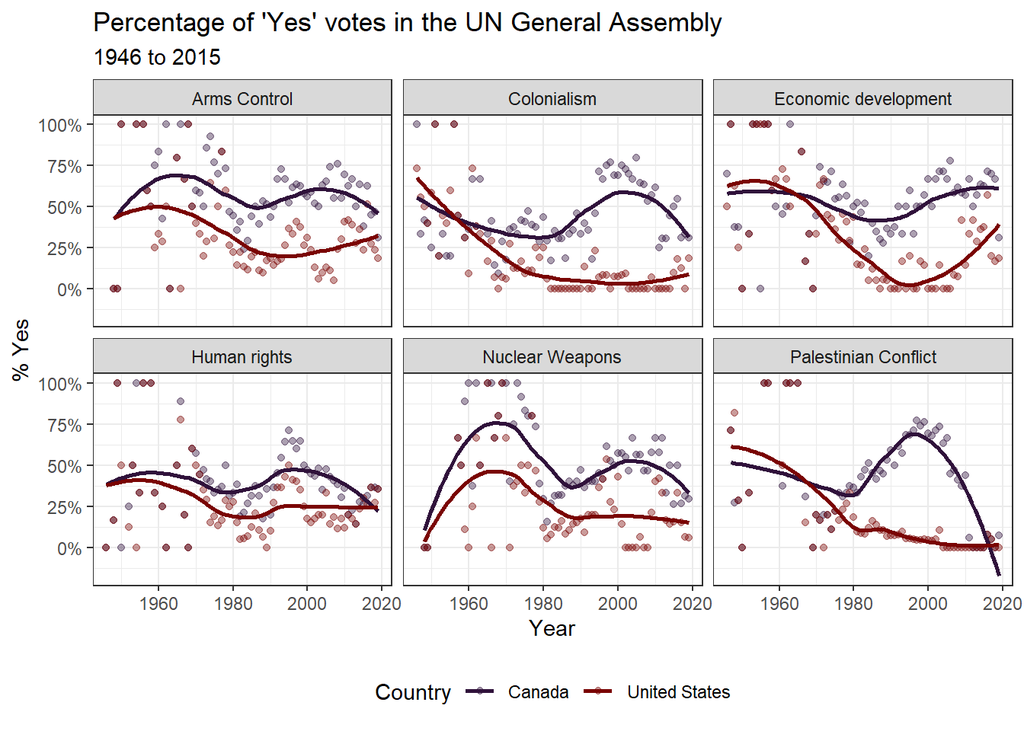

```r
yes_votes |>
  filter(country %in% c("United States","Canada")) |> # select only countries from US and CA
  ggplot(mapping = aes(x = year, y = percent_yes, color = country)) + # Create graph, set x & y axis, color code by country
  geom_point(alpha = 0.4) + # Create scatterplot, set transparency
  #geom_line(aes(group = country)) +
  geom_smooth(method = "loess", se = FALSE) + #this fits a special model called a loess regression, a smooth line that fits the data
  facet_wrap(~issue) + # Divy out plots based on issue variable
  scale_y_continuous(labels = scales::percent) + # Change y-axis scale to percent values
  labs(
    title = "Percentage of 'Yes' votes in the UN General Assembly",
    subtitle = "1946 to 2015",
    y = "% Yes",
    x = "Year",
    color = "Country"
  ) + # Edit and add labels for graph title, subtitle, x & y axis, and legend title
  theme_bw() +
  theme(legend.position = "bottom") + # Move legend position to bottom of graph
  scale_color_viridis_d(option = "turbo") # Adjust the color scheme
```

What do you notice about the voting records over time?

Response by River Mckegney

> Trends across all voting topics tend to follow a similar rise and fall pattern (of yes votes) which repreats itself through time. Topics of arms control, human rights, and nuclear weapons appear to be correlated as they follow similar trends relative to the timescale. Likewise, colonialism, economic development, and the palestinian conflict also appear related to eachother.

# Challenge 2: Adding more data

After your instructor created the above plot, she became curious about how politics might impact the UN Voting record for the United States since UN Ambassador is a presidential appointment. So your instructor started searching for a data set of US presidents, their years in office, and their political affiliation. She found a data set on Kaggle.com and removed the information prior to 1940 (because the dates were coded funny and it was causing problems). She saved the data as `us_presidents.csv` and imported it into the project.

```r
president <- read_csv("data/us_presidents.csv")
```

She realized that her data only had the start/end dates for each president and she wanted a data set that filled in the missing years and political party for the president in that time period. After much googling and reading Stack Overflow, found two functions she did not know about called `complete()` and `fill()` to fill in the missing years and party affiliations

```r
politics_year <- president |>
    mutate(start = lubridate::mdy(start),  #formats date correctly
           start_year = lubridate::year(start)) |> #pulls out year
  filter(start_year > 1940) |>  #removes data before 1940 since there was no UN
  select(start_year, party) |>   #pulls out just the variables of interest
  complete(start_year = seq(min(start_year), 2020, by = 1)) |> #fill in missing years
  fill(party) #fill in missing party affiliations for years

glimpse(politics_year)
```

```
Rows: 76
Columns: 2
$ start_year <dbl> 1945, 1946, 1947, 1948, 1949, 1950, 1951, 1952, 1953, 1954,…
$ party      <chr> "Democratic", "Democratic", "Democratic", "Democratic", "De…
```

Next, your instructor took the `yes_votes` data and filtered out just the United States data and then joined by year to add the party affiliation of the president for each year of UN votes. To create the visualization with the smoothed model, but color by party affiliation, she had to add a new column called `predict` that fit the model first instead of using `geom_smooth()`.

Comment the code below:

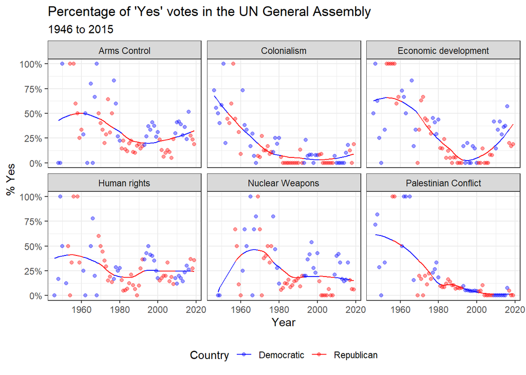

```r
yes_votes |>
  filter(country == "United States") |>  # Filter for US votes
  left_join(politics_year, by = c("year" = "start_year")) |> # Keep yes_votes rows, and matching politics_year rows
  group_by(issue) |>  # Bin issue variables for upcoming calculation
  mutate(predict = predict(loess(percent_yes~year))) |>  # Generate col for smoothline model
  ggplot(mapping = aes(x = year, color = party, group = 1)) + # Create graph, set axes, and color code based on party
  geom_point(aes(y = percent_yes),alpha = 0.4) + # Make scatterplot and set transparency
  geom_line(aes(y = predict)) + # Add smoothline model to scatterplot
  facet_wrap(~issue) + # Subdivide plots based on political issue
  scale_y_continuous(labels = scales::percent) + # Scale y axis by percentage
  labs(
    title = "Percentage of 'Yes' votes in the UN General Assembly",
    subtitle = "1946 to 2015",
    y = "% Yes",
    x = "Year",
    color = "Country"
  ) + # Add labels for title, subtitle, x & y axes, and legend
  theme_bw() + # Add a black & white theme
  scale_color_manual(values = c("blue", "red")) + # Add color scheme
  theme(legend.position = "bottom")  # Adjust legend position to bottom of graph
```

What do you notice? What do you wonder?

Response by River Mckegney